# Semantic Similarity using FastText

**Semantic Similarity using FastText**

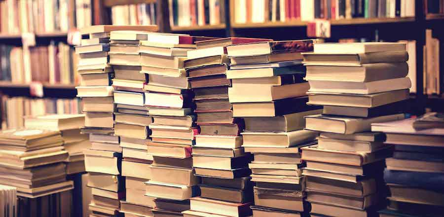

Semantic similarity is a similarity between two words how close their meanings are for the given context (using n-grams) and it is a number between 0 to 1 which tells us how close two words are, semantically. This is done by finding similarity between word vectors in the vector space, (ie) what is the probaility of a context word appearing next to a target word based on corpus of text on which the model has been trained on. we will see how FastText library creates vector representations that can be used to find semantic similarities between the words using skip grams or CBOW.

As a first step, we need to import the required libraries. We will make use of the Wikipedia library for Python, which can be downloaded via the following command:

$ pip install wikipedia

we are using the FastText module from the gensim.models.fasttext library. For the word representation and semantic similarity, we can use the Gensim model for FastText. This model can run on Windows, however, for text classification, we will have to use Linux platform.

**Importing the Necessary Libraries**

```python
import spacy
from gensim.models.fasttext import FastText
import numpy as np
import matplotlib.pyplot as plt
import pandas as pd
import wikipedia
nlp=spacy.load('en_core_web_lg')
%matplotlib inline
```

# Scraping Wikipedia Articles

To scrape a Wikipedia page, we can use the `page` method from the wikipedia module. The name of the page that you want to scrap is passed as a parameter to the page method. The method returns WikipediaPage object, which you can then use to retrieve the page contents via the `content` attribute, as shown in the below script.

```python
artificial_intelligence = wikipedia.page("Artificial Intelligence").content
bible = wikipedia.page("bible book").content
deep_learning = wikipedia.page("Deep Learning").content
neural_network = wikipedia.page("Neural Network").content
marvel = wikipedia.page("marvel books").content
dc = wikipedia.page("dc superheroes").content
```

```python
# print(artificial_intelligence) # we can see the content of the corressponding article below
```

```python
type(artificial_intelligence)
```

```
str
```

Now we will combine all the text into a big corpus by using `extend` method, then we need to convert into corpus of sentences (but not corpus of words , because often the relationship between words will be obtained only in the same sentence which provides its context). Hence if we change the whole text into corpus of words then those meaning will be lost as there is no sentence to learn the context in whcih it has to appear, thus the sentences are important when it comes to semantic similarity.

```python
artificial_intelligence= list(nlp(artificial_intelligence).sents) #to break the given text into sentences first using Spacy
bible= list(nlp(bible).sents)
deep_learning= list(nlp(deep_learning).sents)
neural_network= list(nlp(neural_network).sents)
marvel= list(nlp(marvel).sents)
dc= list(nlp(dc).sents)
```

```python
artificial_intelligence.extend(bible)  #now we will combine all the sentences into a big corpus of sentences
artificial_intelligence.extend(deep_learning)
artificial_intelligence.extend(neural_network)
artificial_intelligence.extend(marvel)
artificial_intelligence.extend(dc)
```

```python
corpus =artificial_intelligence
```

```python
# corpus
```

```python
type(corpus)
```

```
list
```

```python
type(corpus[0])
```

```
spacy.tokens.span.Span
```

As we can see now the sentences won't make much sense now for the machine learning model hence we need to pre-process the text

# Text Pre-processing

After successfully scraping off the content from the coressponding web pages of wikipedia and combines them, we will clean the text data by removing the punctuations and stop words then we have to do Lemmatization to stem the words. We will be using spacy for this Pre-processing whcih is excellent at the Lemmatization process.

```python
def spacy_tokenizer(word):
    a = nlp(word) #tokenization
    b=[]
    for token in a:
        if (token.is_stop != True) and (token.is_punct != True) and (token.is_alpha == True):#Stop words and punc removal
            b.append(token.lemma_) #Lemmatization
    return b
```

```python
final_corpus = [spacy_tokenizer(str(sent)) for sent in corpus]
```

```python
final_corpus[ 0:3] # first 3 sentences
```

```
[['artificial',
  'intelligence',
  'AI',
  'intelligence',
  'demonstrate',
  'machine',
  'unlike',
  'natural',
  'intelligence',
  'display',
  'human',
  'animal'],
 ['lead',
  'AI',
  'literature',
  'define',
  'field',
  'study',
  'intelligent',
  'agent',
  'device',
  'perceive',
  'environment',
  'take',
  'action',
  'maximize',
  'chance',
  'successfully',
  'achieve',
  'goal'],
 ['colloquially',
  'term',
  'artificial',
  'intelligence',
  'describe',
  'machine',
  'computer',
  'mimic',
  'cognitive',
  'function',
  'human',
  'associate',
  'human',
  'mind',
  'learn',
  'problem',
  'solve']]
```

You can see the punctuations and stop words have been removed, and the sentences have been lemmatized and ready for modelling

```python
final_corpus[0] #first sentence words
```

```
['artificial',
 'intelligence',
 'AI',
 'intelligence',
 'demonstrate',
 'machine',
 'unlike',
 'natural',
 'intelligence',
 'display',
 'human',
 'animal']
```

```python
final_corpus[77] #78th sentence words
```

```
['champion', 'Brad', 'Rutter', 'Ken', 'Jennings', 'significant', 'margin']
```

**FastText Model**

```python
embedding_size = 60
window_size = 30
min_word = 5
down_sampling = 1e-2

ft_model = FastText(final_corpus,size=embedding_size,window=window_size,min_count=min_word,sample=down_sampling,sg=1,iter=100)
```

Here `embedding_size` is the size of the embedding vector. In other words, each word in our corpus will be represented as a 60-dimensional vector.

The next hyper-parameter is the `min_word`, which specifies the minimum frequency of a word in the corpus for which the word representations will be generated.

All the parameters in the above script are self-explanatory, except sg. The `sg` parameter defines the type of model that we want to create. A value of 1 specifies that we want to create skip-gram model. Whereas zero specifies the bag of words model, which is the default value as well

Finally, the most frequently occurring word will be down-sampled by a number specified by the `down_sampling` attribute.

Let's now see the word representation for the word "artificial". To do so, you can use the wv method of the FastText object and pass it the name of the word inside a list.

```python
print(ft_model.wv['artificial'])
```

```
[-0.11516774 -0.34735596  0.04007773 -0.08333723  0.12733498  0.29892465
 -0.44941792  0.08193046 -0.4208426   0.00178034 -0.27667725 -0.27798438
 -0.37278867 -0.35378233  0.6035039   0.44976708 -0.87247056  0.07884907
  0.53284913  0.07238454  0.18758087 -0.3458625  -0.05991274 -0.45489076
  0.57202315 -0.36800665  0.01566056  0.3776745  -0.9311271   0.21638656
  0.25294852 -0.33161974 -0.00498661 -0.08199129  0.15755172 -0.4950718
 -0.10033881 -0.25137067  0.545285    0.22768083  0.14193657 -0.29316866
  0.2259333   0.45709872 -0.22549455 -0.03218947  0.01222909 -0.4088482
 -0.33082414  0.20196827 -0.1426936  -0.19130383 -0.02102066 -0.84173983
  0.74341244 -0.35167173 -0.2066791   0.09982372  0.03009558  0.51219726]
```

we can also find the similarity between two words by using the `wv.most_similar` method of the ft_model and extract the top n similar words which are closer semantically

```python
semantically_similar_words = {words: [item[0] for item in ft_model.wv.most_similar([words], topn=8)]
                  for words in ['artificial', 'god', 'network', 'jesus','satan','heroes','superman', 'steve rogers']}

for k,v in semantically_similar_words.items():
    print(k+":"+str(v)+'\n')
```

```
artificial:['intelligence', 'biological', 'neural', 'machine', 'Intelligence', 'Artificial', 'behavior', 'network']

god:['good', 'authority', 'Christianity', 'Holy', 'God', 'humanity', 'actually', 'difficulty']

network:['neural', 'neuron', 'biological', 'processing', 'model', 'deep', 'learning', 'approximation']

jesus:['Jesus', 'holy', 'Jeremiah', 'Wisdom', 'Timothy', 'Letter', 'Baruch', 'Prayer']

satan:['Stan', 'Lee', 'artist', 'Jim', 'amazing', 'Kirby', 'Doctor', 'guardian']

heroes:['Superheroes', 'DC', 'Heroes', 'Mattel', 'figure', 'Superman', 'Super', 'Batman']

superman:['Superman', 'League', 'Justice', 'superhero', 'Black', 'Batman', 'America', 'Doctor']

steve rogers:['Avengers', 'guardian', 'collectible', 'Galaxy', 'Doctor', 'Daredevil', 'Iron', 'Hulk']
```

We can also sue the `doesnt_match` to seggregate the context meaning between multiple words and detect the odd one out as below:

```python
# here batman and superman comes under the comic context but the jesus is under the bible context
# so the doesnt_match method will calculate teh similarity between the given words based on the context between them
# and expel the odd one out
ft_model.wv.doesnt_match('batman superman jesus'.split())
```

```
'jesus'
```

```python
# here eventhough all words comes under the comic dimensionality the batman and superman are heroes while lexluthor is a villain
ft_model.wv.doesnt_match('batman superman luthor'.split())
```

```
'luthor'
```

```python
# here machine and artificial are under the machine learning context and superman is comic context
ft_model.wv.doesnt_match('machine artificial superman'.split())
```

```
'superman'
```

```python
# here machine and artificial are under the machine learning context and satan is bible context
ft_model.wv.doesnt_match('machine artificial satan'.split())
```

```
'satan'
```

```python
# here it is a diff perespective as jesus and holy are god while judas is the betrayer
ft_model.wv.doesnt_match('Judas Jesus holy'.split())
```

```
'Judas'
```

# Visualizing Word Similarities

Though each word in our model is represented as 60-dimensional vector, we can use principal component analysis technique to find two principal components. The two principal components can then be used to plot the words in a two dimensional space. However, first we need to create a list of all the words in the semantically_similar_words dictionary. The following script does that:

```python
from sklearn.decomposition import PCA

all_similar_words = sum([[k] + v for k, v in semantically_similar_words.items()], [])

print(all_similar_words)
print(type(all_similar_words))
print(len(all_similar_words))
```

[output not shown]

[figure not shown]

```python
word_vectors = ft_model.wv[all_similar_words]

pca = PCA(n_components=2)

p_comps = pca.fit_transform(word_vectors)
word_names = all_similar_words

plt.figure(figsize=(18, 10))
plt.scatter(p_comps[:, 0], p_comps[:, 1], c='red')

for word_names, x, y in zip(word_names, p_comps[:, 0], p_comps[:, 1]):
    plt.annotate(word_names, xy=(x+0.06, y+0.03), xytext=(0, 0), textcoords='offset points')
```